# Data 624 Homework 10

Anthony Pagan

5/3/2020

# Introduciton

Imagine 10000 receipts sitting on your table. Each receipt represents a transaction with items that were purchased. The receipt is a representation of stuff that went into a customer’s basket - and therefore ‘Market Basket Analysis’.

That is exactly what the Groceries Data Set contains: a collection of receipts with each line representing 1 receipt and the items purchased. Each line is called a transaction and each column in a row represents an item. The data set is attached.

Your assignment is to use R to mine the data for association rules. You should report support, confidence and lift and your top 10 rules by lift.

# Data Summary

```
## transactions as itemMatrix in sparse format with
##  9835 rows (elements/itemsets/transactions) and
##  169 columns (items) and a density of 0.02609146
##
## most frequent items:
##       whole milk other vegetables       rolls/buns             soda
##             2513             1903             1809             1715
##           yogurt          (Other)
##             1372            34055
##
## element (itemset/transaction) length distribution:
## sizes
##    1    2    3    4    5    6    7    8    9   10   11   12   13   14   15   16
## 2159 1643 1299 1005  855  645  545  438  350  246  182  117   78   77   55   46
##   17   18   19   20   21   22   23   24   26   27   28   29   32
##   29   14   14    9   11    4    6    1    1    1    1    3    1
##
##    Min. 1st Qu.  Median    Mean 3rd Qu.    Max.
##   1.000   2.000   3.000   4.409   6.000  32.000
##
## includes extended item information - examples:
##             labels
## 1 abrasive cleaner
## 2 artif. sweetener
## 3   baby cosmetics
```

# Frequency Plot

**The frequency plot gives us 2 other ways to look at populuar items, absolute and relative. The absolute plot details a specific item on the plot while the relative plot shows the item in relation to other items on the datsset. Both plots have similar listed items and frequencies.**

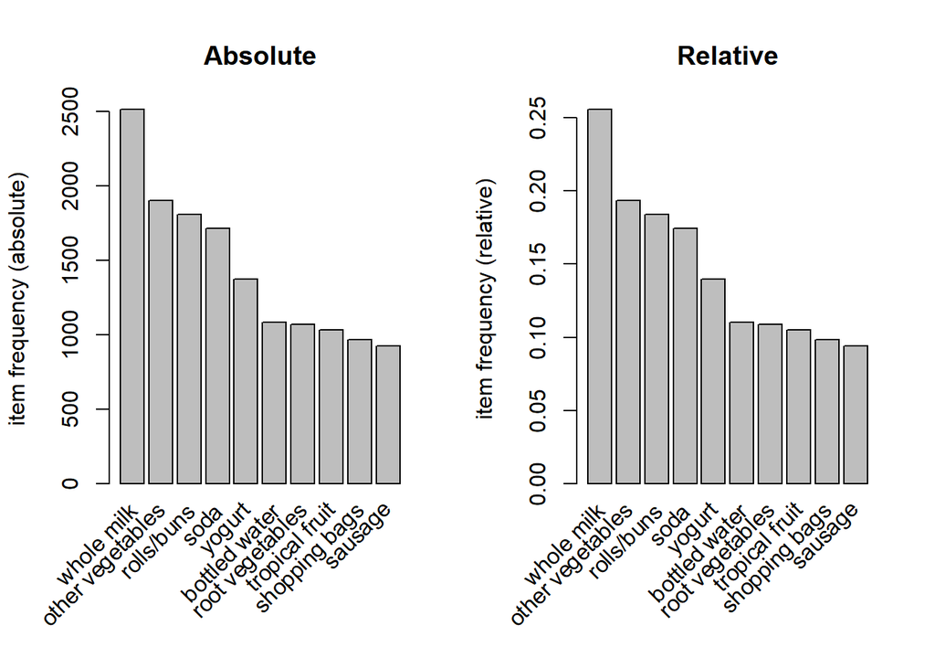

# Rules Plot

```
## Apriori
##
## Parameter specification:
##  confidence minval smax arem  aval originalSupport maxtime support minlen
##        0.49    0.1    1 none FALSE            TRUE       5    0.01      1
##  maxlen target   ext
##      10  rules FALSE
##
## Algorithmic control:
##  filter tree heap memopt load sort verbose
##     0.1 TRUE TRUE  FALSE TRUE    2    TRUE
##
## Absolute minimum support count: 98
##
## set item appearances ...[0 item(s)] done [0.00s].
## set transactions ...[169 item(s), 9835 transaction(s)] done [0.01s].
## sorting and recoding items ... [88 item(s)] done [0.00s].
## creating transaction tree ... done [0.01s].
## checking subsets of size 1 2 3 4 done [0.00s].
## writing ... [19 rule(s)] done [0.00s].
## creating S4 object  ... done [0.00s].
```

```
## set of 19 rules
##
## rule length distribution (lhs + rhs):sizes
##  2  3
##  2 17
##
##    Min. 1st Qu.  Median    Mean 3rd Qu.    Max.
##   2.000   3.000   3.000   2.895   3.000   3.000
##
## summary of quality measures:
##     support          confidence          lift           count
##  Min.   :0.01007   Min.   :0.4902   Min.   :1.919   Min.   : 99.0
##  1st Qu.:0.01118   1st Qu.:0.5010   1st Qu.:2.016   1st Qu.:110.0
##  Median :0.01230   Median :0.5175   Median :2.162   Median :121.0
##  Mean   :0.01430   Mean   :0.5312   Mean   :2.255   Mean   :140.6
##  3rd Qu.:0.01459   3rd Qu.:0.5665   3rd Qu.:2.406   3rd Qu.:143.5
##  Max.   :0.02755   Max.   :0.5862   Max.   :3.030   Max.   :271.0
##
## mining info:
##  data ntransactions support confidence
##  gcds          9835    0.01       0.49
```

```
##      lhs                        rhs                   support confidence     lift count
## [1]  {curd}                  => {whole milk}       0.02613116  0.4904580 1.919481   257
## [2]  {butter}                => {whole milk}       0.02755465  0.4972477 1.946053   271
## [3]  {curd,
##       yogurt}                => {whole milk}       0.01006609  0.5823529 2.279125    99
## [4]  {butter,
##       other vegetables}      => {whole milk}       0.01148958  0.5736041 2.244885   113
## [5]  {domestic eggs,
##       other vegetables}      => {whole milk}       0.01230300  0.5525114 2.162336   121
## [6]  {fruit/vegetable juice,
##       other vegetables}      => {whole milk}       0.01047280  0.4975845 1.947371   103
## [7]  {whipped/sour cream,
##       yogurt}                => {other vegetables} 0.01016777  0.4901961 2.533410   100
## [8]  {whipped/sour cream,
##       yogurt}                => {whole milk}       0.01087951  0.5245098 2.052747   107
## [9]  {other vegetables,
##       whipped/sour cream}    => {whole milk}       0.01464159  0.5070423 1.984385   144
## [10] {other vegetables,
##       pip fruit}             => {whole milk}       0.01352313  0.5175097 2.025351   133
## [11] {citrus fruit,
##       root vegetables}       => {other vegetables} 0.01037112  0.5862069 3.029608   102
## [12] {root vegetables,
##       tropical fruit}        => {other vegetables} 0.01230300  0.5845411 3.020999   121
## [13] {root vegetables,
##       tropical fruit}        => {whole milk}       0.01199797  0.5700483 2.230969   118
## [14] {tropical fruit,
##       yogurt}                => {whole milk}       0.01514997  0.5173611 2.024770   149
## [15] {root vegetables,
##       yogurt}                => {other vegetables} 0.01291307  0.5000000 2.584078   127
## [16] {root vegetables,
##       yogurt}                => {whole milk}       0.01453991  0.5629921 2.203354   143
## [17] {rolls/buns,
##       root vegetables}       => {other vegetables} 0.01220132  0.5020921 2.594890   120
## [18] {rolls/buns,
##       root vegetables}       => {whole milk}       0.01270971  0.5230126 2.046888   125
## [19] {other vegetables,
##       yogurt}                => {whole milk}       0.02226741  0.5128806 2.007235   219
```

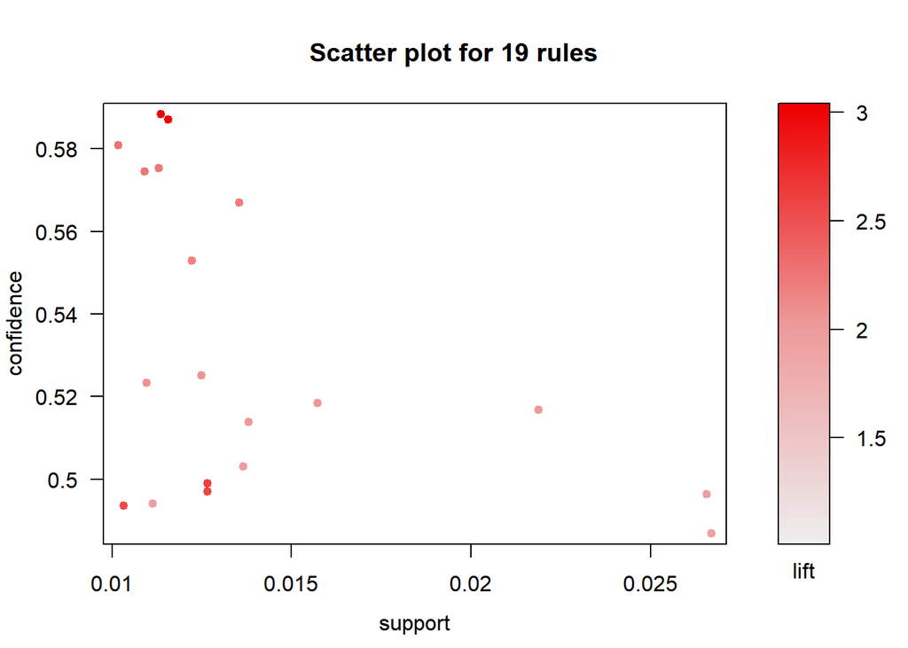

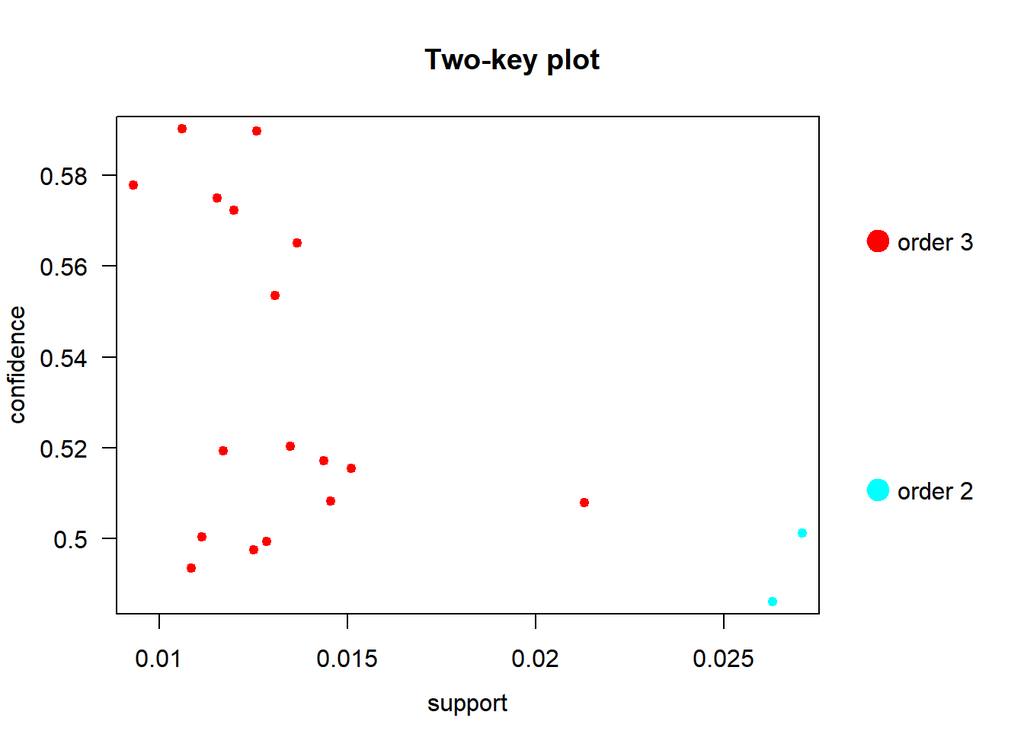

# Lift and Confidence Plot

**Lift gives us how likely item Y is purchased when X is purchased while controlling Y. Below we are plotting the lift and confidence of each item.**

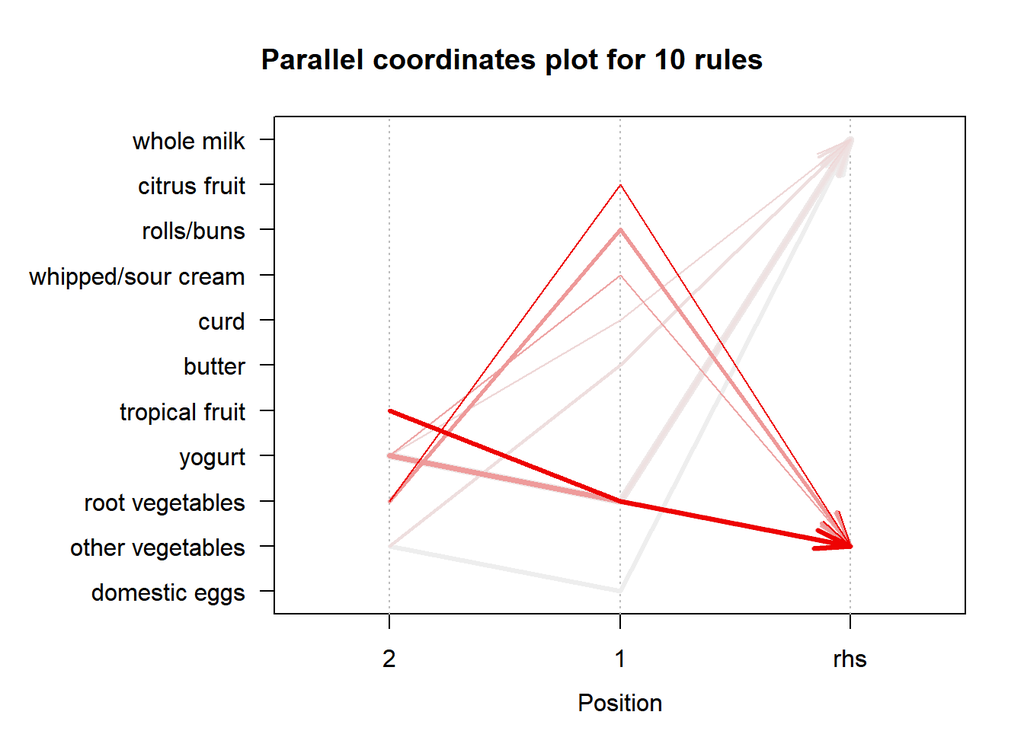

[interactive chart not shown]

# Cluster Analysis

**The cluster plot groups similar rules, then shows grouped distribution of the rules. In the below plots we are we are using 10 as the number of clusters**

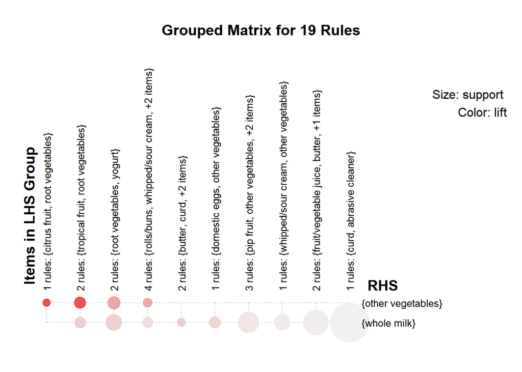

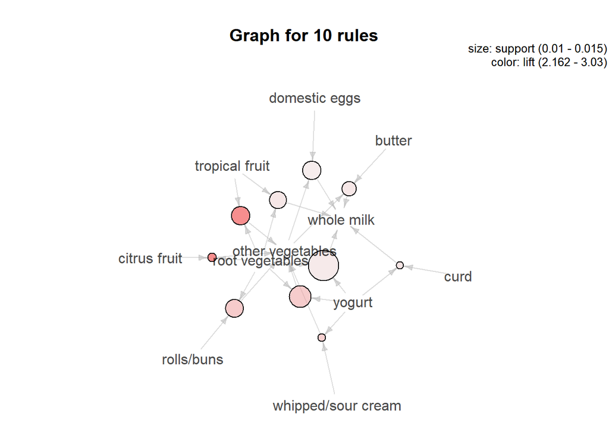

# APPENDIX

**Code used in analysis**

```r
knitr::opts_chunk$set(
    echo = FALSE,
    message = FALSE,
    warning = FALSE
)
#knitr::opts_chunk$set(echo = TRUE)
require(knitr)
library(ggplot2)
library(tidyr)
library(MASS)
library(psych)
library(kableExtra)
library(dplyr)
library(faraway)
library(gridExtra)
library(reshape2)
library(leaps)
library(pROC)
library(caret)
library(naniar)
library(pander)
library(pROC)
library(mlbench)
library(e1071)
library(fpp2)
library(mlr)
library(arules)
library(arulesViz)
library(cluster)
library(igraph)
library(visNetwork)
gcds <- read.transactions("GroceryDataSet.csv", header = F, format = 'basket', sep=',')
summary(gcds)
#itemFrequency(gcds)
par(mfrow=c(1,2))
itemFrequencyPlot(gcds, topN=10, type="absolute", main="Absolute")
itemFrequencyPlot(gcds, topN=10, type="relative", main="Relative")

rules<-apriori(gcds, parameter = list(supp=0.01, conf=.49))
summary(rules)
inspect(rules)

plot(rules, jitter=3)
plot(rules, jitter=3, method = "two-key plot")

top10rules2<-head(rules, n=10, by = "lift")
plot(top10rules2,  method = "paracoord")
top10rules<-head(rules, n=10, by = "confidence")
plot(top10rules, method = "graph", engine = "htmlwidget")



plot(rules, method = "grouped", control = list(k = 10))
subrules <- head(sort(rules, by = "lift"), 10)
plot(subrules, method = "graph")
```